# Day 2: Maps

# Imports and starter code

```r
library(dplyr)
library(ggplot2)
# scale bars and north arrows
library(ggspatial)
# maps
library(rnaturalearth)
# map data
library(rnaturalearthdata)
# high-resolution maps
library(rnaturalearthhires)
#' simple features' package
library(sf)
# interactive thematic maps
library(tmap)

# Our malaria dataset
df <- read.csv("../../data/Malaria_Dataset_DataViz.csv")

# Where all the map data is located
map_folder <- "../../data/maps"

# Rivers
rivers <- ne_load(
  scale = 10,
  type = "rivers_lake_centerlines",
  destdir = map_folder,
  returnclass = "sf"
)
# Lakes
lakes <- ne_load(
  scale = 10,
  type = "lakes",
  destdir = map_folder,
  returnclass = "sf"
)
# Oceans
oceans <- ne_load(
  scale = 10,
  type = "ocean",
  destdir = map_folder,
  returnclass = "sf"
)
```

# Exercise 1: plot the world

Use the `rnaturalearth` and `ggplot2` libraries to get the country outlines on a world map

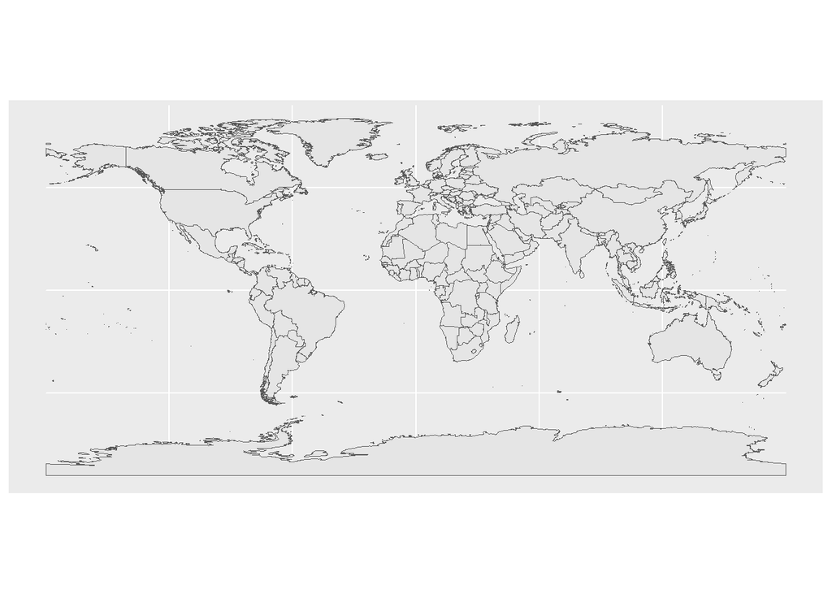

```r
# Use rnaturalearth to get all countries ("ne_countries")
world_ne <- ne_countries(
  scale = "medium", # map scale
  returnclass = "sf" # return a Simple Features dataframe
)

# We use geom_sf from ggplot to draw simple boundaries and outlines
ggplot(data = world_ne) +
  geom_sf() # geom to visualise sf objects
```

# Exercise 2: Kenya plot a Kenya map?

Plot a high-definition map of Kenya supplemented with information on:

- Scale
- Orientation (North/South)
- Coordinates (longitude/latitude)

**Hint:** use `ggspatial`

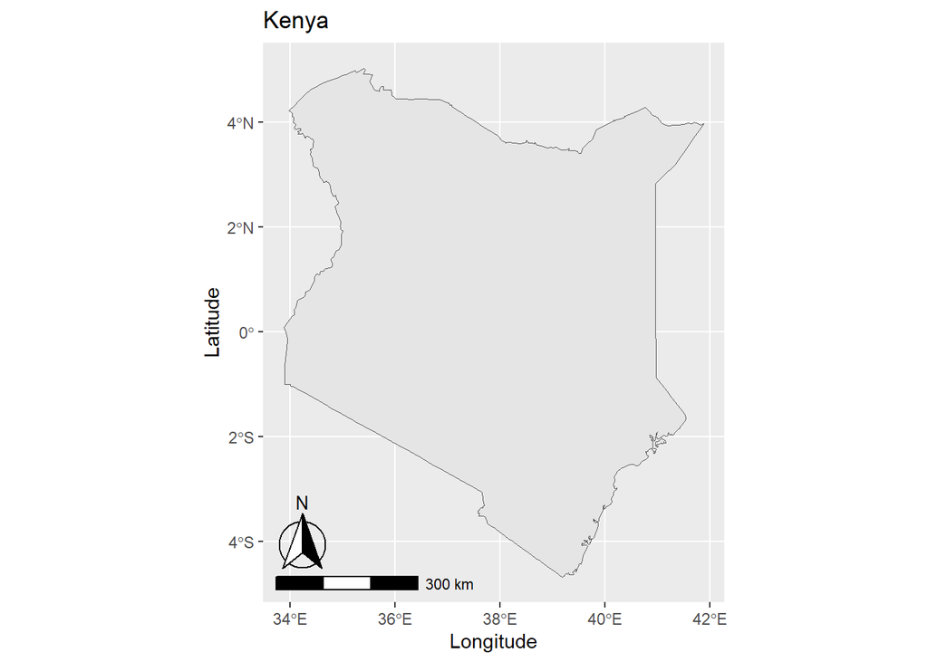

```r
# Use rnaturalearth to get the country polygon for Kenya
kenya <- ne_countries(
  country = "kenya", # country name
  type = "countries", # country type
  scale = "large", # requires rnaturalhires
  returnclass = "sf"
)

# Basic Kenya map
kenya_map <- ggplot(data = kenya) +
  geom_sf()

kenya_map_detailed <- kenya_map +
  # Add labels
  labs(
    x = "Longitude",
    y = "Latitude",
    title = "Kenya"
  ) +
  # Add the scale on the bottom left (ggspatial)
  annotation_scale(location = "bl", width_hint = 0.4) +
  # Add a north arrow on the bottom left (ggspatial)
  annotation_north_arrow(
    location = "bl",
    which_north = "true",
    pad_x = unit(0.0, "in"),
    pad_y = unit(0.2, "in"),
    style = north_arrow_fancy_orienteering
  )

kenya_map_detailed
```

# Exercise 3: Kenya add more details?

Augment your Kenya plot by adding:

- a point for 3 major cities: Nairobi, the capital, as well as Mombasa and Nakuru.
- lakes, rivers, and potential surrounding oceans

You might have to do a bit of googling to get the coordinates 😀

**Hint:** use `sf` and the data in the starter code!

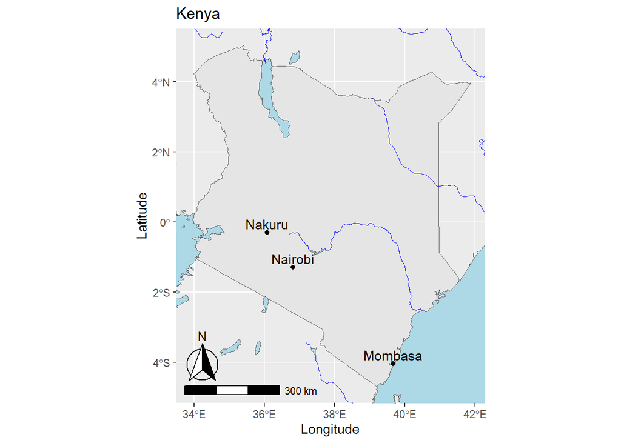

```r
# Kenya data for major cities
kenya_city_data <- data.frame(
  city_name = c("Nairobi", "Mombasa", "Nakuru"),
  lat = c(-1.2921, -4.0435, -0.3031),
  lon = c(36.8219, 39.6682, 36.0800)
)

# Bounding box coordinates for Kenya
kenya_coords <- st_bbox(kenya)
xmin <- kenya_coords[1]
xmax <- kenya_coords[3]
ymin <- kenya_coords[2]
ymax <- kenya_coords[4]

kenya_map_very_detailed <- kenya_map_detailed +
  # Add rivers
  geom_sf(data = rivers, colour = "blue", linewidth = 0.2) +
  # Add lakes
  geom_sf(data = lakes, fill = "lightblue") +
  # Add oceans
  geom_sf(data = oceans, fill = "lightblue") +
  # Restict coordinates for rivers/lakes/oceans
  coord_sf(xlim = c(xmin, xmax), ylim = c(ymin, ymax)) +
  # Add points for cities (scatter plot)
  geom_point(
    data = kenya_city_data,
    mapping = aes(x = lon, y = lat),
    colour = "black"
  ) +
  # Add annotation
  geom_text(
    data = kenya_city_data,
    mapping = aes(x = lon, y = lat, label = city_name),
    nudge_y = 0.25,
    color = "black"
  )

kenya_map_very_detailed
```

# Exercise 4: Kenya add survey data?

Last touch to our map! add the coordinates for surveys in our dataset (`df`) performed in Kenya

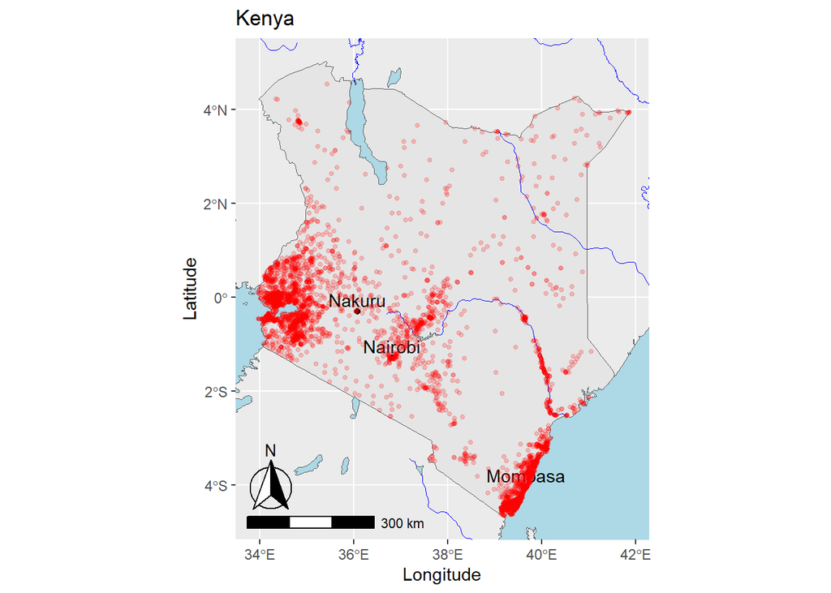

```r
kenya_df <- df %>% filter(country == "Kenya")

kenya_map_very_detailed +
  # Scatter plot with x = longitude, y = latitude
  geom_point(
    data = kenya_df,
    mapping = aes(x = longitude, y = latitude),
    colour = "red",
    alpha = 0.2,
    size = 1
  )
```

# Exercise 5: thematic maps with `tmap`

*Warning!* You might have to delete your current environment before doing this exercise and/or do it on a separate R script.

Let’s have a look at interactive thematic maps with `tmap`!

We provide you with some starter code below. `World` is a `data.frame` with a special column that contains a geometry for each row, in this case polygons.

```r
# Interactive mode
tmap_mode("view")

# Load World Data
data("World")

# Show the first rows
head(World)
```

```
## Simple feature collection with 6 features and 15 fields
## Geometry type: MULTIPOLYGON
## Dimension:     XY
## Bounding box:  xmin: -73.41544 ymin: -55.25 xmax: 75.15803 ymax: 42.68825
## Geodetic CRS:  WGS 84
##   iso_a3                 name           sovereignt     continent
## 1    AFG          Afghanistan          Afghanistan          Asia
## 2    AGO               Angola               Angola        Africa
## 3    ALB              Albania              Albania        Europe
## 4    ARE United Arab Emirates United Arab Emirates          Asia
## 5    ARG            Argentina            Argentina South America
## 6    ARM              Armenia              Armenia          Asia
##                area  pop_est pop_est_dens                   economy
## 1  652860.00 [km^2] 28400000     43.50090 7. Least developed region
## 2 1246700.00 [km^2] 12799293     10.26654 7. Least developed region
```

[output cut: 18 more lines]

Try to plot a few economic indicators for African countries. Can we talk about an “economic burden” for malaria in African countries? Is this enough evidence?

```r
# Select Africa
africa <- World %>% filter(continent == "Africa")

# Rough estimation of average PfPr (parasite rate) in each country
df %>%
  group_by(country) %>%
  summarize(PfPr_mean = mean(PfPr)) %>%
  arrange(desc(PfPr_mean))
```

```
## # A tibble: 44 × 2
##    country                  PfPr_mean
##    <chr>                        <dbl>
##  1 Central African Republic     0.998
##  2 Burkina Faso                 0.600
##  3 Equatorial Guinea            0.598
##  4 Comoros                      0.496
##  5 Guinea                       0.478
##  6 Congo                        0.429
##  7 Sierra Leone                 0.424
##  8 Mali                         0.410
##  9 Togo                         0.410
## 10 Ghana                        0.395
## # ℹ 34 more rows
```

```r
# You can plot several columns at once with tm_facets
tm_shape(africa) +
  # Plot life expectancy and GDP per capita
  tm_polygons(
    col = c("life_exp", "gdp_cap_est", "economy"),
    palette = list("Blues", "Blues", "Reds"),
    id = "name"
  ) +
  tm_facets(sync = TRUE, ncol = 3)
```

[interactive chart not shown]